# Week 6 Short Answer Questions

## Gretchen Greene

Compiled on Sat Apr 8 10:58:50 2017.

12.1, 12.2, 12.3 13.1, 13.2, 13.3, 13.4 14.1, 14.3, 14.7, 14.10

12.1)

```r
BabyNames %>%
  group_by(sex, name) %>%
  summarise( total = sum (count)) %>%
  mutate(namescore= rank(desc(total)))%>%
  filter(namescore <=5)
```

```
## Source: local data frame [10 x 4]
## Groups: sex [2]
##
##      sex      name   total namescore
##    <chr>     <chr>   <int>     <dbl>
## 1      F Elizabeth 1591439         2
## 2      F  Jennifer 1461186         4
## 3      F     Linda 1450328         5
## 4      F      Mary 4112464         1
## 5      F  Patricia 1570135         3
## 6      M     James 5091189         1
## 7      M      John 5073958         2
## 8      M   Michael 4293460         4
## 9      M    Robert 4789776         3
## 10     M   William 4038447         5
```

top 5 female names: Mary, Elizabeth, Patricia, Jennifer, Linda top 5 male names: James, John, Robert, Michael, William

12.2)

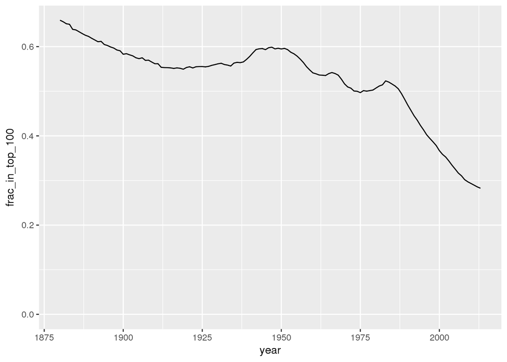

```r
PopularCounts <-
  BabyNames %>%
  group_by(year,name)%>%
  summarise(count = sum(count))%>%
  mutate(frac_in_top_100 = rank(desc(count)) <= 100) %>%
  group_by(year, frac_in_top_100)%>%
  summarise(total = sum(count))

GlyphReady <-
  PopularCounts %>%
  spread(frac_in_top_100, total)%>%
  mutate(frac_in_top_100 = `TRUE`/(`TRUE` + `FALSE`))

GlyphReady %>%
  ggplot(aes(x=year, y= frac_in_top_100)) + geom_line() + ylim(0,NA)
```

12.3) a) summary function b) neither summary nor transformation. It is a pair of values not a single value which is necessary for a summary function c) summary function d) transformation function e) transformation function f) summary function g) transformation function h) summary function. The whole set of dates is turned into a single value.

13.1) 1) 7 verticies; China, germany, France, UK, Italy, USA, USSR 2) 9 edges

13.2) 1) A, C, B, D 2) Table 2 3) Table 1 shows an ede from B to C but there is no edge between B and C. Table 3 shows an edge between three points. Edges only are between 2 vertices.

13.3) Table 2 gives the information needed to draw the graph shown.

13.4) 1. Exports is mapped to the size of the letter. 2. Pop is mapped to the shape of the gray symbol.

14.1)

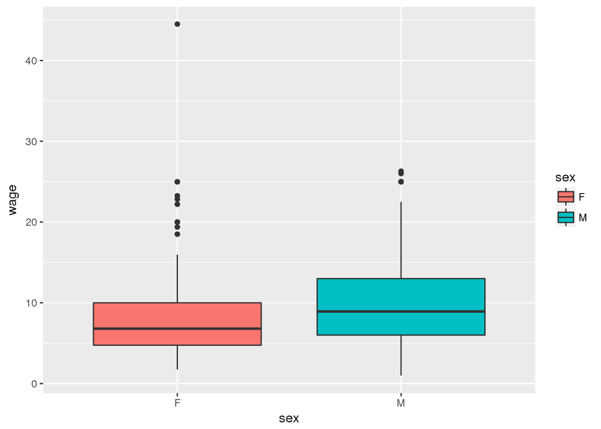

```r
mosaicData::CPS85 %>%
  ggplot(aes(x = sex, y= wage)) + geom_boxplot(aes(fill= sex))
```

14.3) The most likely hieght for women is around 1.55 m and for men around 1.7 m.

14.7)

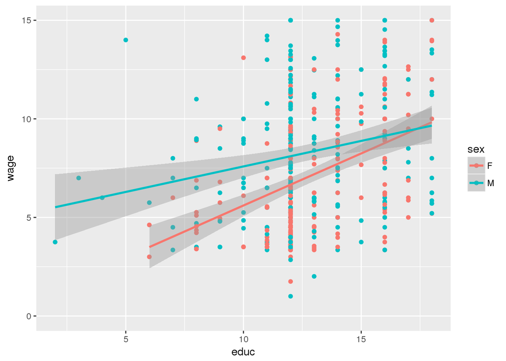

```r
mosaicData::CPS85 %>%
  ggplot(aes(x =educ, y= wage, color= sex)) +
  geom_point() +
  stat_smooth(method = "lm") +
  ylim (0, 15)
```

14.10)

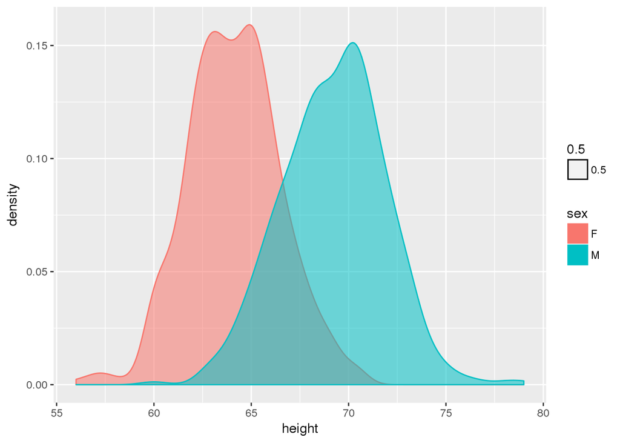

```r
mosaicData::Galton %>%
  ggplot( aes( x= height, group = sex)) +
  geom_density( aes( color = sex, fill = sex, alpha = 0.5))
```